# SVM

We will use a problem from the back of the book to demonstrate SVM. We will use the Auto dataset to predict whether a given car gets high or low gas mileage. (a) Create a binary variable that takes on a 1 for cars with gas mileage above the median, and a 0 for cars with gas mileage below the median. (b) Fit a support vector classifier to the data with various values of cost, in order to predict whether a car gets high or low gas mileage. Report the cross-validation errors associated with different values of this parameter. Comment on your results. Note you will need to fit the classifier without the gas mileage variable to produce sensible results. (c) Now repeat (b), this time using SVMs with radial and polynomial basis kernels, with different values of gamma and degree and cost. Comment on your results. (d) Make some plots to back up your assertions in (b) and (c).

```r
# Load the required libraries
library(ISLR2)
library(caret)
library(MASS)
library(MLeval)
library(tidyverse)
library(data.table)
set.seed(1234)
```

```r
dt <- Auto %>% select(-name)
```

Create a new dataframe to remove missing values and delete the column name

1. Create a binary variable that takes on a 1 for cars with gas mileage above the median, and a 0 for cars with gas mileage below the median.

```r
dt$mpg <- as.factor(ifelse(dt$mpg > median(dt$mpg), "YES", "NO"))
```

2. Fit a support vector classifier to the data with various values of cost, in order to predict whether a car gets high or low gas mileage. Report the cross-validation errors associated with different values of this parameter. Comment on your results. Note you will need to fit the classifier without the gas mileage variable to produce sensible results.

We will use the caret package to divide the data into testing and training sets

```r
rowPicker <- createDataPartition(y=dt$mpg, p=0.8, list=FALSE)
train <- dt[rowPicker,]
test <- dt[-rowPicker,]
```

Initialize the trainControl

```r
control <- trainControl(method = "cv", number = 10, classProbs = TRUE,
                        summaryFunction = twoClassSummary,
                        savePredictions = TRUE)
```

Create a grid of vales for the tuning parameter C

```r
tGrid <- expand.grid(C = c(.01, .05, .1, .25, .5, .75, 1, 1.25, 5, 10))
```

Estimate the SVM Model

```r
svmModel <- train(mpg ~ ., train, method = "svmLinear", tuneGrid = tGrid,
                  trControl = control, metric = "ROC",
                  preProcess = c("center", "scale"))
svmModel
```

```
Support Vector Machines with Linear Kernel

314 samples
  7 predictor
  2 classes: 'NO', 'YES'

Pre-processing: centered (7), scaled (7)
Resampling: Cross-Validated (10 fold)
Summary of sample sizes: 282, 282, 282, 283, 284, 283, ...
Resampling results across tuning parameters:

  C      ROC        Sens       Spec
   0.01  0.9732969  0.9108333  0.9491667
   0.05  0.9692865  0.9108333  0.9491667
   0.10  0.9720469  0.9108333  0.9491667
   0.25  0.9716042  0.9045833  0.9495833
   0.50  0.9728021  0.9045833  0.9562500
   0.75  0.9728021  0.9045833  0.9437500
   1.00  0.9732188  0.8983333  0.9500000
   1.25  0.9736076  0.9112500  0.9370833
   5.00  0.9744132  0.8983333  0.9495833
  10.00  0.9732413  0.8987500  0.9433333

ROC was used to select the optimal model using the largest value.
The final value used for the model was C = 5.
```

Check performance of the linear model

```r
svmPred <- predict(svmModel, test)
confusionMatrix(svmPred, test$mpg)
```

```
Confusion Matrix and Statistics

          Reference
Prediction NO YES
       NO  30   4
       YES  9  35

               Accuracy : 0.8333
                 95% CI : (0.7319, 0.9082)
    No Information Rate : 0.5
    P-Value [Acc > NIR] : 9.039e-10

                  Kappa : 0.6667

 Mcnemar's Test P-Value : 0.2673

            Sensitivity : 0.7692
            Specificity : 0.8974
         Pos Pred Value : 0.8824
         Neg Pred Value : 0.7955
             Prevalence : 0.5000
         Detection Rate : 0.3846
   Detection Prevalence : 0.4359
      Balanced Accuracy : 0.8333

       'Positive' Class : NO
```

3. Now repeat (b), this time using SVMs with radial and polynomial basis kernels, with different values of gamma and degree and cost. Comment on your results.

create a range of values for sigma and C

```r
rGrid <- expand.grid(C = c(.1, .25, .5, .75, 1, 1.25, 1.5),
                     sigma = c(1e-3, 1e-2, 1e-1))
```

Model with Radial Kernel

```r
radModel <- train(mpg ~ ., train, method = "svmRadial", tuneGrid = rGrid,
                  trControl = control, metric = "ROC",
                  preProcess = c("center", "scale"))
radModel
```

```
Support Vector Machines with Radial Basis Function Kernel

314 samples
  7 predictor
  2 classes: 'NO', 'YES'

Pre-processing: centered (7), scaled (7)
Resampling: Cross-Validated (10 fold)
Summary of sample sizes: 282, 283, 283, 283, 282, 283, ...
Resampling results across tuning parameters:

  C     sigma  ROC        Sens       Spec
  0.10  0.001  0.9665625  0.7616667  0.9250000
  0.10  0.010  0.9701823  0.9045833  0.9558333
  0.10  0.100  0.9786458  0.8983333  0.9558333
  0.25  0.001  0.9665625  0.8187500  0.9808333
  0.25  0.010  0.9726042  0.9045833  0.9558333
  0.25  0.100  0.9814063  0.9045833  0.9495833
  0.50  0.001  0.9673958  0.9045833  0.9558333
  0.50  0.010  0.9737760  0.9108333  0.9495833
  0.50  0.100  0.9826042  0.9045833  0.9495833
  0.75  0.001  0.9698177  0.9045833  0.9558333
  0.75  0.010  0.9729688  0.9108333  0.9495833
  0.75  0.100  0.9822396  0.9045833  0.9620833
  1.00  0.001  0.9698177  0.9045833  0.9558333
  1.00  0.010  0.9733594  0.9108333  0.9558333
  1.00  0.100  0.9810417  0.9045833  0.9620833
  1.25  0.001  0.9722135  0.9045833  0.9620833
  1.25  0.010  0.9733594  0.9108333  0.9558333
  1.25  0.100  0.9801823  0.9045833  0.9625000
  1.50  0.001  0.9718229  0.9045833  0.9558333
  1.50  0.010  0.9729688  0.9108333  0.9433333
  1.50  0.100  0.9793490  0.8920833  0.9625000

ROC was used to select the optimal model using the largest value.
The final values used for the model were sigma = 0.1 and C = 0.5.
```

Check performance of the radial kernel model

```r
radPred <- predict(radModel, test)
confusionMatrix(radPred, test$mpg)
```

```
Confusion Matrix and Statistics

          Reference
Prediction NO YES
       NO  28   4
       YES 11  35

               Accuracy : 0.8077
                 95% CI : (0.7027, 0.8882)
    No Information Rate : 0.5
    P-Value [Acc > NIR] : 1.874e-08

                  Kappa : 0.6154

 Mcnemar's Test P-Value : 0.1213

            Sensitivity : 0.7179
            Specificity : 0.8974
         Pos Pred Value : 0.8750
         Neg Pred Value : 0.7609
             Prevalence : 0.5000
         Detection Rate : 0.3590
   Detection Prevalence : 0.4103
      Balanced Accuracy : 0.8077

       'Positive' Class : NO
```

Model with polynomial Kernel

```r
polyModel <- train(mpg ~ ., train, method = "svmPoly",
                  trControl = control, metric = "ROC",
                  preProcess = c("center", "scale"))
polyModel
```

```
Support Vector Machines with Polynomial Kernel

314 samples
  7 predictor
  2 classes: 'NO', 'YES'

Pre-processing: centered (7), scaled (7)
Resampling: Cross-Validated (10 fold)
Summary of sample sizes: 282, 283, 284, 282, 282, 282, ...
Resampling results across tuning parameters:

  degree  scale  C     ROC        Sens       Spec
  1       0.001  0.25  0.9702622  0.7908333  0.9750000
  1       0.001  0.50  0.9702622  0.8250000  0.9483333
  1       0.001  1.00  0.9714583  0.9037500  0.9550000
```

[output cut: 27 more lines]

Check performance of the polynomial model

```r
polyPred <- predict(polyModel, test)
confusionMatrix(polyPred, test$mpg)
```

```
Confusion Matrix and Statistics

          Reference
Prediction NO YES
       NO  29   5
       YES 10  34

               Accuracy : 0.8077
                 95% CI : (0.7027, 0.8882)
    No Information Rate : 0.5
    P-Value [Acc > NIR] : 1.874e-08

                  Kappa : 0.6154

 Mcnemar's Test P-Value : 0.3017

            Sensitivity : 0.7436
            Specificity : 0.8718
         Pos Pred Value : 0.8529
         Neg Pred Value : 0.7727
             Prevalence : 0.5000
         Detection Rate : 0.3718
   Detection Prevalence : 0.4359
      Balanced Accuracy : 0.8077

       'Positive' Class : NO
```

Compute ROC curves to compare the models using MLeval package

```
***MLeval: Machine Learning Model Evaluation***
Input: caret train function object
Not averaging probs.
Group 1 type: cv
Group 2 type: cv
Group 3 type: cv
Observations: 942
Number of groups: 3
Observations per group: 314
Positive: YES
Negative: NO
Group: Linear SVC
Positive: 157
Negative: 157
Group: Radial SVM
Positive: 157
Negative: 157
Group: Polynomial SVM
Positive: 157
Negative: 157
***Performance Metrics***
Linear SVC Optimal Informedness = 0.86624203821656
Radial SVM Optimal Informedness = 0.872611464968153
Polynomial SVM Optimal Informedness = 0.89171974522293
Linear SVC AUC-ROC = 0.97
Radial SVM AUC-ROC = 0.98
Polynomial SVM AUC-ROC = 0.98
```

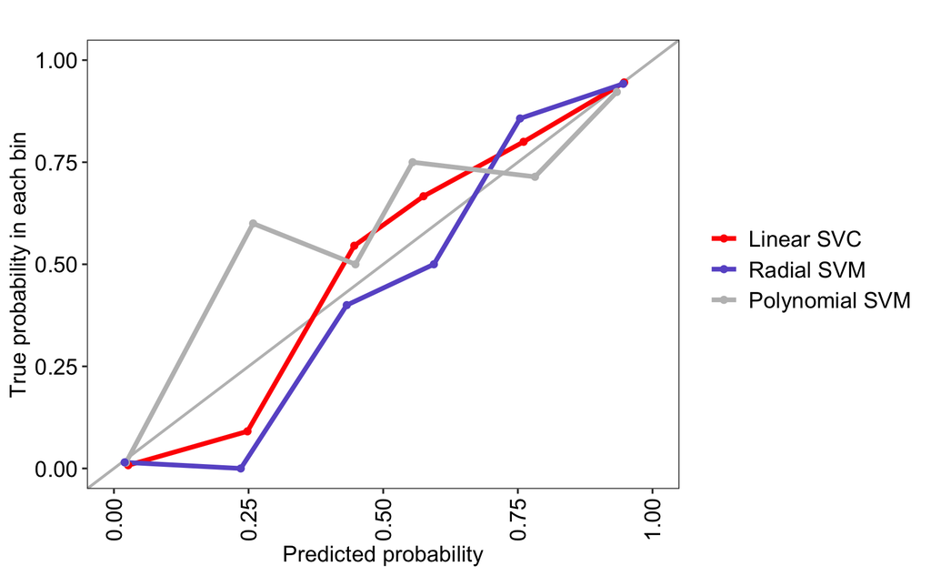

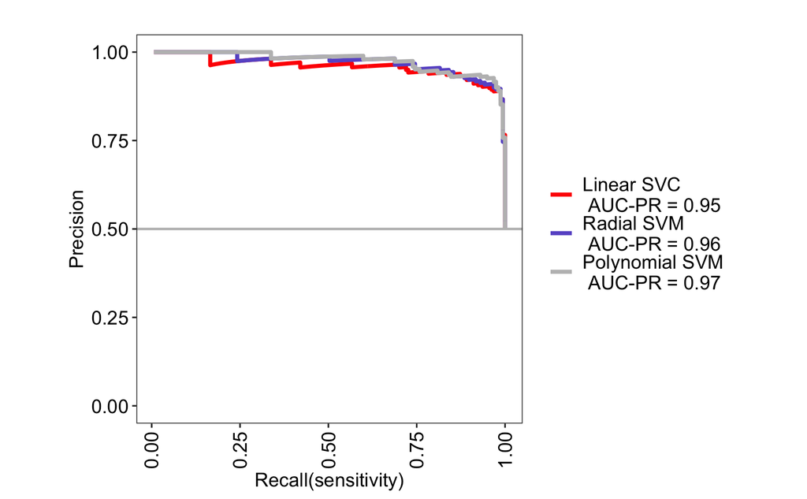

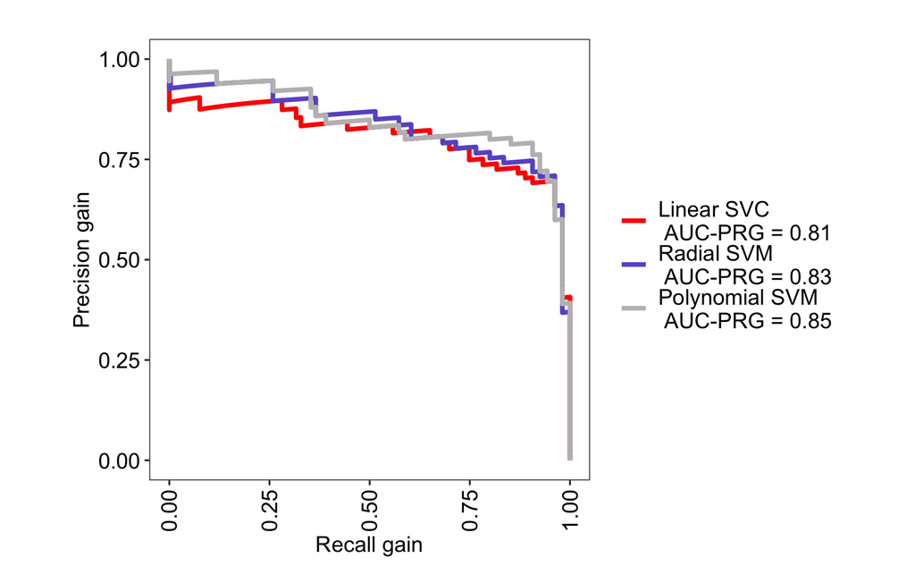

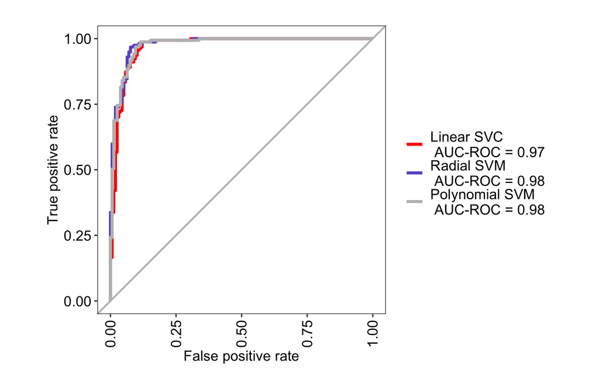

```r
plot_comp <- evalm(list1 = list(svmModel, radModel, polyModel),
                   gnames = c("Linear SVC", "Radial SVM", "Polynomial SVM"))
```